# Статистика - 1 (набір 2026)

*Ваші відповіді ніде не зберігаються, нікуди не передаються. Цей опитувальник для само-контролю.*

#### Це блок питань по Заняттю 1, де показано, які перші кроки робить науковець, коли вже знає, що досліджує.

## 1 Планування дослідження

### 1.1 Шлях дослідника

Оберіть, що найкраще відповідає правильному шляху науковця:

Маю уявлення про феномен → формулюю очікуваний висновок → шукаю підтвердження своїх уявлень → збираю дані, які мають їх підтвердити → відкидаю або ігнорую суперечливі результати → роблю висновок, який підтверджує початкові уявлення → оформлюю в статтю, подаю → звітую Маю гарні знання в певній темі → тисне дедлайн виконання гранту/теми/дисертації → формулюю питання, для якого можна швидко зібрати дані → збираю доступні дані → доручаю ШІ провести аналіз і написати статтю → перевіряю галюцинації → подаю рукопис в журнал → звітую, про подання публікації як виконаний етап роботи Цікавлюсь темою, багато читаю → формулюю дослідницьке питання та гіпотези, які можна перевірити → визначаю, що буду вимірювати → збираю дані → досліджую дані → підбираю методи → описую методи → аналізую, оцінюю наскільки результати підтримують гіпотези → інтерпретую → роблю висновки з урахуванням невизначенності та обмежень дослідження → оформлюю в статтю, подаю → звітую

Правильний шлях, а не той, який буває в реальності :)

### 1.2 Дизайн дослідження

Щоб дослідити можливий причинний вплив збирання грибів на їх видове різноманіття, дослідник планує експеримент.

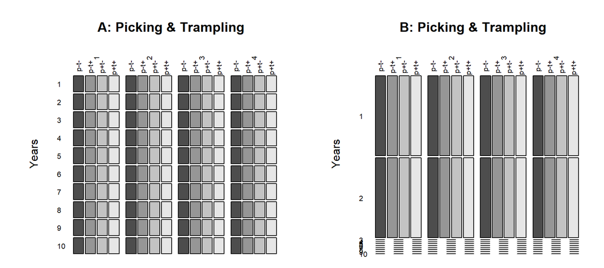

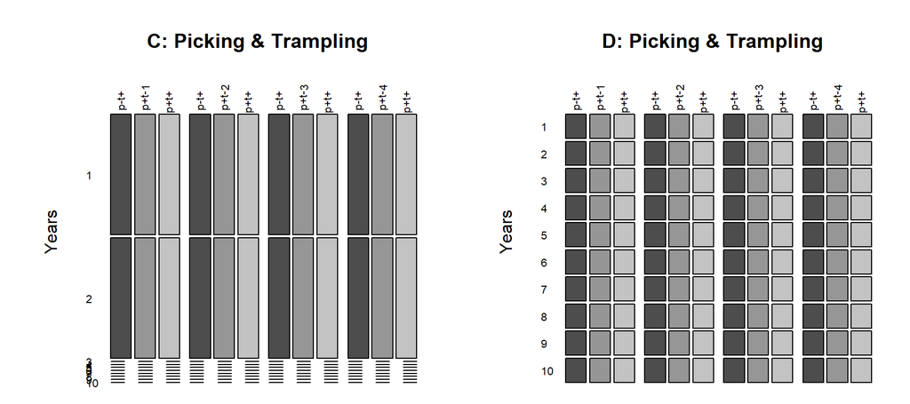

Який дизайн відповідає цій меті? Який може бути прийнятним?

A B C D

Дивитись тут: https://www.sciencedirect.com/science/article/abs/pii/S0953756208618833 https://www.sciencedirect.com/science/article/abs/pii/S0006320705004726

### 1.3 Розчарування результатом - що робити?

Результати не підтвердили вашу початкову гіпотезу. Що робити?

Приховати результати, які не відповідають очікуванням Змінити дані, щоб вони відповідали очікуванням Інтерпретувати результати на основі наявних даних, чесно описати обмеження та за потреби переосмислити питання

Дані мають визначати висновки, а не підганятися під очікування. Мету дослідження можна переосмислити з огляду на те, що дозволяють дані.

## 2 Вибір методів

### 2.1 Узагальнення

Описова статистика узагальнює наявні дані за допомогою таблиць, графіків, середніх, медіан, квартилів тощо. Ви хочете описати розподіл розміру тіла у дослідженій вибірці, не роблячи висновків про ширшу популяцію.

Що це?

Статистичне узагальнення Описова статистика

### 2.2 Візуалізація

Це одні і ті самі дані візуалізовані з допомогою гістограми, але з різною кількістю інтервалів.

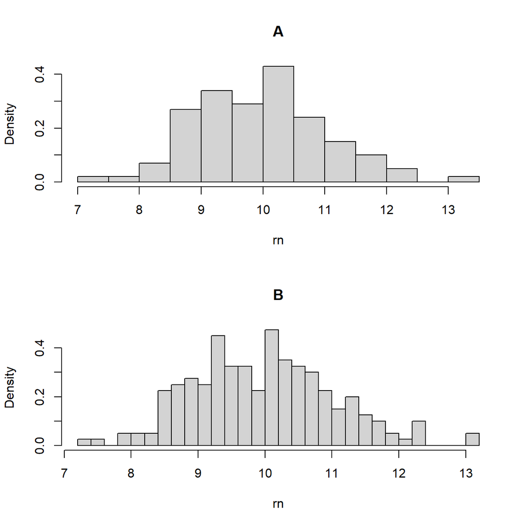

Скільки тут груп?

1 2

## 3 Аналіз

### 3.1 Значущість

Яке твердження про p-значення відповідає представленому в лекції традиційному (частотному) підходу? Наприклад, ви досліджуєте вімінності між двома популяціями.

Що таке p-value?

Це ймовірність істинності нульової гіпотези Це ймовірність отримати саме цю гіпотезу після перегляду даних Це ймовірність отримати такі ж результати або більш екстремальні за умови, що нульова гіпотеза правдива, P(data|H0)

Нульова гіпотеза: групи однакові.

Результат більш екстремальний: якщо p = 0.03, то при правдивій Н0, ваш шанс, що відмінності, які ви спостерігаєте, є випадковими = 3%.

### 3.2 Баєсівський підхід

Як формулюється завдання для аналізу при Баєсівському підході? Наприклад, ви досліджуєте вімінності між двома популяціями.

Чи однакові популяції? Яка саме різниця між ними і наскільки ми в ній впевнені? P(H|data)

При Баєсівському підході дослідник чітко розуміє:

1. Що знаємо про явище. Формулюємо priors. Якщо припущень нема, то використовуємо неінформативний розподіл = усі варіанти відмінностей між групами однаково ймовірні). Зважаємо, що розподід треба обмежити не абсурдними значеннями. Якщо до нас вже досліджували явище, то використовуємо, наприклад нормальний розподіл: найбільш ймовірні відмінності між групами дорівнюють значенню Х з коливанням в межах +-3 одиниць.
2. Оцінюємо функцію правдоподібності (likelihood). Ймовірність отримати наші конкретні дані при різних варіантах реальної відмінності.
3. Поєднуємо prior + likelihood = отримаємо апостеріорний розподіл (Posterior probability).

### 3.3 Причинність

Ви виявили статистично значущу різницю між ділянками (p = 0.1e-4), де випалювали рослинність, і контрольними ділянками.

Що можна стверджувати?

Випалювання точно спричинило різницю, особливо якщо p < 0.05 Значуща різниця сама по собі не доводить, що її спричинило випалювання

Cтатистичні відмінності між ділянками самі по собі не означають причинного ефекту випалювання.

## 4 Оформлення результатів

Яка практика найкраще допомагає іншим дослідникам перевірити та відтворити ваш результат?

Опублікувати достатній опис матеріалів і методів Зберегти сирі дані та надати код аналізу Опублікувати лише графіки та p-значення Скоротити максимально статтю за рахунок методів